# Project1

Mark Shocklee

Saturday, November 08, 2014

## Setup

```r
require(knitr)
```

```r
opts_chunk$set(fig.width=12, fig.height=8, fig.path='./figure',
               echo=TRUE, warning=FALSE, message=FALSE)
```

## Loading and preprocessing the data

Show any code that is needed to:

- Load the data (i.e. read.csv())
- Process/transform the data (if necessary) into a format suitable for your analysis

The file for this project was downloaded on 11/8/2014 10:17 AM from http://github.com/rdpeng/RepData_PeerAssessment1.

```r
dir.create("data")
unzip("activity.zip", exdir = "./data", overwrite=TRUE)
activity <- read.csv("./data/activity.csv", na.strings = "NA")
dir.create("figure")
```

Get some basic information about the file.

```r
summary(activity)
```

```
##      steps               date          interval
##  Min.   :  0.0   2012-10-01:  288   Min.   :   0
##  1st Qu.:  0.0   2012-10-02:  288   1st Qu.: 589
##  Median :  0.0   2012-10-03:  288   Median :1178
##  Mean   : 37.4   2012-10-04:  288   Mean   :1178
##  3rd Qu.: 12.0   2012-10-05:  288   3rd Qu.:1766
##  Max.   :806.0   2012-10-06:  288   Max.   :2355
##  NA's   :2304    (Other)   :15840
```

```r
head(activity)
```

```
##   steps       date interval
## 1    NA 2012-10-01        0
## 2    NA 2012-10-01        5
## 3    NA 2012-10-01       10
## 4    NA 2012-10-01       15
## 5    NA 2012-10-01       20
## 6    NA 2012-10-01       25
```

```r
tail(activity)
```

```
##       steps       date interval
## 17563    NA 2012-11-30     2330
## 17564    NA 2012-11-30     2335
## 17565    NA 2012-11-30     2340
## 17566    NA 2012-11-30     2345
## 17567    NA 2012-11-30     2350
## 17568    NA 2012-11-30     2355
```

## Processing prior to Imputing Missing Values

For this part of the assignment, you can ignore the missing values in the dataset.

- What is mean total number of steps taken per day?

```r
total_steps <- aggregate(steps ~ date, data = activity, FUN = sum)
# Based upon the comments by the TA in the Discussion Forums, these calculations
# are not used.
mean_steps <- aggregate(steps ~ date, data = activity, FUN = mean)
median_steps <- aggregate(steps ~ date, data = activity, FUN = median)
# The forums indicate that these are the correct calculations.
mean_total_steps <- mean(total_steps$steps)
median_total_steps <- median(total_steps$steps)
```

- Make a histogram of the total number of steps taken each day

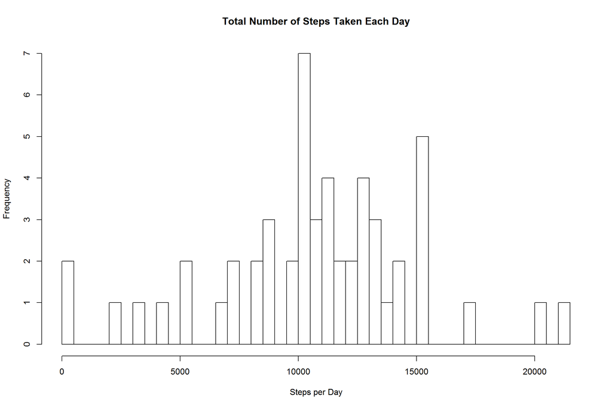

```r
hist(total_steps$steps,
     breaks = nrow(total_steps),
     main = "Total Number of Steps Taken Each Day",
     xlab = "Steps per Day")
```

```r
dev.copy(png,
         filename = "./figure/plot1.png",
         width = 480,
         height = 480,
         units = "px",
         bg = "white")
```

```r
dev.off()
```

- Calculate and report the mean and median total number of steps taken per day

The mean of total number of steps taken per day is 10,766

The median of total number of steps taken per day is 10,765

- What is the average daily activity pattern?
- Make a time series plot (i.e. type = “l”) of the 5-minute interval (x-axis) and the average number of steps taken, averaged across all days (y-axis)

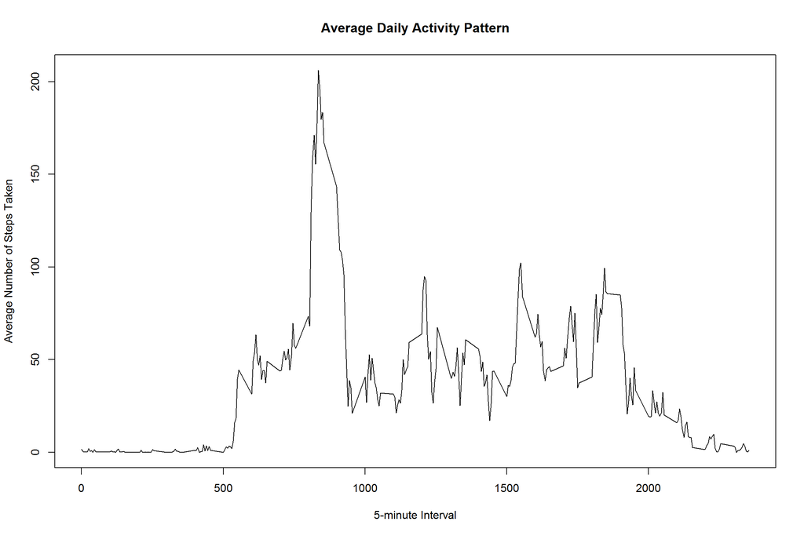

```r
time_series_average <- aggregate(steps ~ interval, data = activity, FUN = mean)

plot(x = time_series_average$interval,
y = time_series_average$steps,
type = 'l',
main = "Average Daily Activity Pattern",
xlab = "5-minute Interval",
ylab = "Average Number of Steps Taken")
```

- Which 5-minute interval, on average across all the days in the dataset, contains the maximum number of steps?

```r
max_interval <- time_series_average[which.max(time_series_average$steps),
                                   "interval"]
```

The 5-minute interval that contains the maximum number of steps is 835

Comments: I didn’t really like the whole 5-minute interval thing. Given that there should be 12 intervals per hour and 288 intervals per day, we should be able to guess, within a period of 5 minutes, when the device was turned on and then convert the interval to a time of day. It would have been more interesting to figure out when the user was most active and see if we could determine any other activity patterns from the data.

## Imputing missing values

Note that there are a number of days/intervals where there are missing values (coded as NA). The presence of missing days may introduce bias into some calculations or summaries of the data.

- Calculate and report the total number of missing values in the dataset (i.e. the total number of rows with NAs)

```r
missing_count <- sum(is.na(activity$steps)) #This better match the summary
```

The total number of missing values is 2,304

- Devise a strategy for filling in all of the missing values in the dataset. The strategy does not need to be sophisticated. For example, you could use the mean/median for that day, or the mean for that 5-minute interval, etc.

Comments: This was an interesting part of the assignment, at least from a research perspective (it remains to be seen whether I can actually use any of the items I discovered.) There seems to be several missing data imputation packages that are available:

```
    Visualization and Imputation of Missing values -- Templ, M., Alfons, A., & Kowarik, A. (2010a). Package available at http://cran.r-project.org/web/packages/VIM/VIM.pdf

    Amelia II -- Honaker, J., King, G., & Blackwell, M. (2010a). Package available at http://cran.r-project.org/web/packages/Amelia/Amelia.pdf

    mvnmle -- Gross, K., & Bates, D. (2009). Package available at http://cran.r-project.org/web/packages/mvnmle/mvnmle.pdf

    k nearest neighbor (knn) -- Kim, K., & Yi, G. (2009). Package available at http://cran.r-project.org/web/packages/SeqKnn/SeqKnn.pdf

    Stack Overflow had several examples of doing various things to replace missing values -- http://stackoverflow.com
```

- Create a new dataset that is equal to the original dataset but with the missing data filled in.

I’m going to try using the Amelia II package just to see how it works. The documentation indicates that there is a user interfact that is used to generate the output files. I hope that I won’t be penalized if that is the case and I just get an output file to use.

```r
require(Amelia) #Going to try this to see what happens.
activity$date<-as.Date(activity$date)
amelia_out <- amelia(activity, m = 5, p2s = 1, )
```

```
## -- Imputation 1 --
##
##   1  2
##
## -- Imputation 2 --
##
##   1  2
##
## -- Imputation 3 --
##
##   1  2
##
## -- Imputation 4 --
##
##   1  2
##
## -- Imputation 5 --
##
##   1  2
```

```r
summary(amelia_out)
```

```
##
## Amelia output with 5 imputed datasets.
## Return code:  1
## Message:  Normal EM convergence.
##
## Chain Lengths:
## --------------
## Imputation 1:  2
## Imputation 2:  2
## Imputation 3:  2
## Imputation 4:  2
## Imputation 5:  2
##
## Rows after Listwise Deletion:  15264
## Rows after Imputation:  17568
## Patterns of missingness in the data:  2
##
## Fraction Missing for original variables:
## -----------------------------------------
##
##          Fraction Missing
## steps              0.1311
## date               0.0000
## interval           0.0000
```

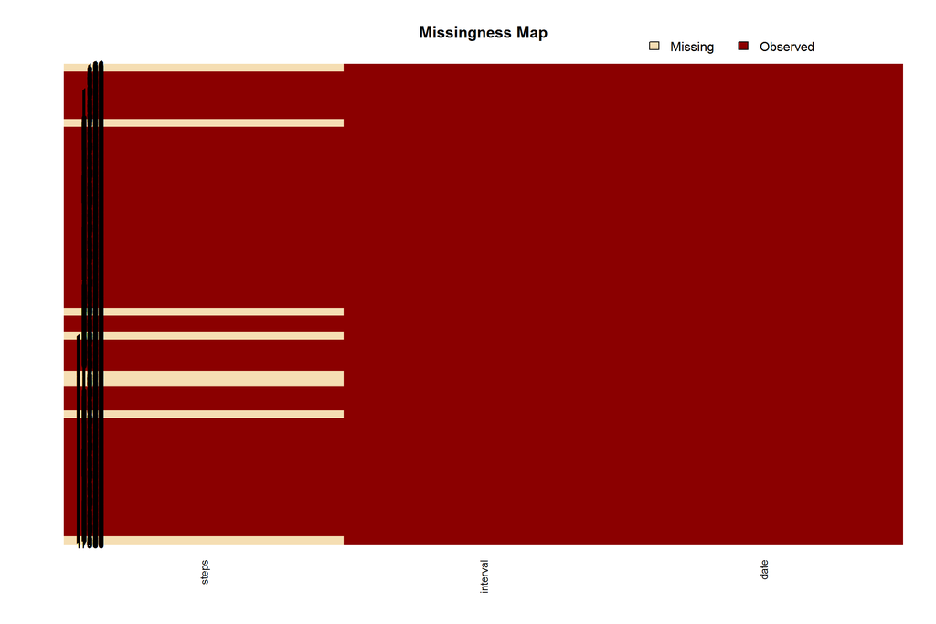

```r
missmap(amelia_out)
```

```r
summary(amelia_out$imputations[[5]])
```

```
##      steps             date               interval
##  Min.   :-366.4   Min.   :2012-10-01   Min.   :   0
##  1st Qu.:   0.0   1st Qu.:2012-10-16   1st Qu.: 589
##  Median :   0.0   Median :2012-10-31   Median :1178
##  Mean   :  37.4   Mean   :2012-10-31   Mean   :1178
##  3rd Qu.:  26.0   3rd Qu.:2012-11-15   3rd Qu.:1766
##  Max.   : 806.0   Max.   :2012-11-30   Max.   :2355
```

```r
imputed_activity <- activity #Make a copy
imputed_activity[!complete.cases(imputed_activity),]
```

[output not shown]

[output cut: 2290 more lines]

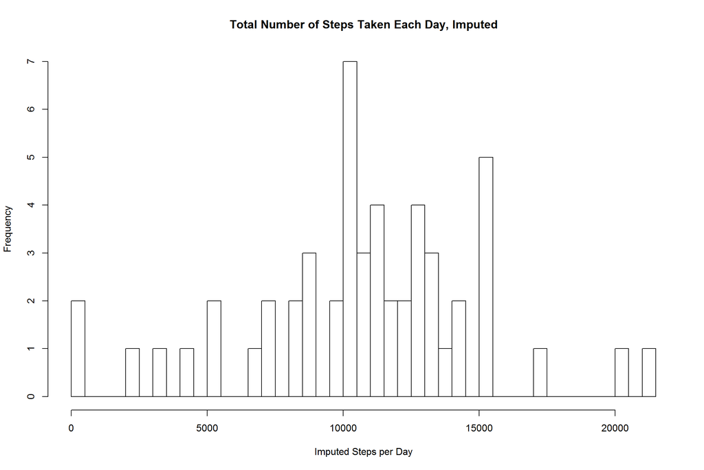

```r
imputed_total_steps <- aggregate(steps ~ date,
                                 data = imputed_activity,
                                 FUN = sum)
imputed_mean_total_steps <- mean(imputed_total_steps$steps)
imputed_median_total_steps <- median(imputed_total_steps$steps)
hist(imputed_total_steps$steps,
     breaks = nrow(total_steps),
     main = "Total Number of Steps Taken Each Day, Imputed",
     xlab = "Imputed Steps per Day")
```

```r
dev.copy(png,
         filename = "./figure/plot2.png",
         width = 480,
         height = 480,
         units = "px",
         bg = "white")
```

```r
dev.off()
```

- Are there differences in activity patterns between weekdays and weekends?

For this part the weekdays() function may be of some help here. Use the dataset with the filled-in missing values for this part.

- Create a new factor variable in the dataset with two levels  “weekday” and “weekend” indicating whether a given date is a weekday or weekend day.

```r
imputed_activity$date <- as.Date(imputed_activity$date)
imputed_activity$dayofweek <- weekdays(imputed_activity$date)
imputed_activity$weekend <- factor(imputed_activity$dayofweek
                                   %in% c("Saturday", "Sunday"),
                                   labels = c("Weekday", "Weekend"))
```

- Make a panel plot containing a time series plot (i.e. type = “l”) of the 5-minute interval (x-axis) and the average number of steps taken, averaged across all weekday days or weekend days (y-axis). See the README file in the GitHub repository to see an example of what this plot should look like using simulated data.

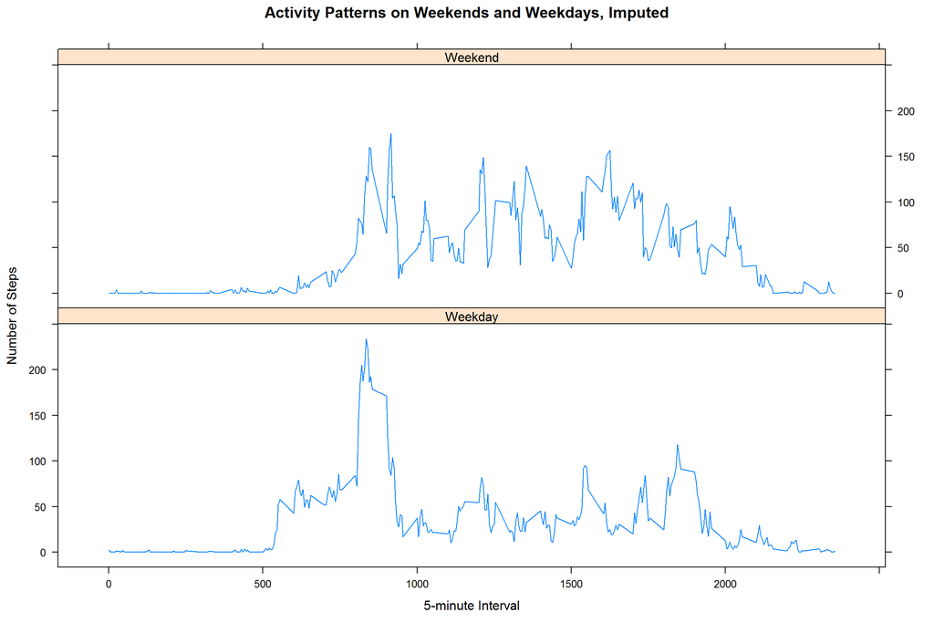

```r
activity_by_interval <- aggregate(imputed_activity$steps,
                                  list("interval" = imputed_activity$interval,
                                       "weekend" = imputed_activity$weekend),
                                  mean, na.rm = TRUE,
                                  simplify = TRUE)
require(lattice)
xyplot(activity_by_interval$x ~ activity_by_interval$interval
       | activity_by_interval$weekend,
       type = "l",
       layout = c(1,2),
       xlab = "5-minute Interval",
       ylab = "Number of Steps",
       main = "Activity Patterns on Weekends and Weekdays, Imputed")
```

```r
dev.copy(png,
         filename = "./figure/plot3.png",
         width = 480,
         height = 480,
         units = "px",
         bg = "white")
```

```r
dev.off()
```